### 12월/3주

#### ▶ ▣ 정당지지도 ▣

더불어민주당 45.2%, 국민의힘 36.7%, 정의당 1.5%, 기타 정당 4.7%, 지지하는 정당이 없다 11.3%, 잘 모르겠다 0.6%

#### ▶ ▣ 대통령 국정 수행 평가 ▣

잘하고 있다 38.9%, 잘못하고 있다 59.7%, 잘 모르겠다 1.5%

#### ☑ ▣ 총선 프레임 공감 ▣

원활한 국정수행을 뒷받침하기 위해 여당인 국민의힘에 힘을 실어 줘야 한다 37.2%, 현 정권 견제를 위해서 제1야당인 민주당에 힘을 실어 줘야 한다 46.6%, 기존 양당이 아닌 제3세력에 힘을 실어 줘야 한다 16.3%

#### ☑ ▣ 이낙연 신당 지지 의향 ▣

지지할 의향이 매우 크다 18.0%, 지지할 의향이 있는 편이다 14.7%, 별로 지지할 의향 없다 18.7%, 전혀 지지할 의향이 없다 45.2%, 잘 모르겠다 3.4%

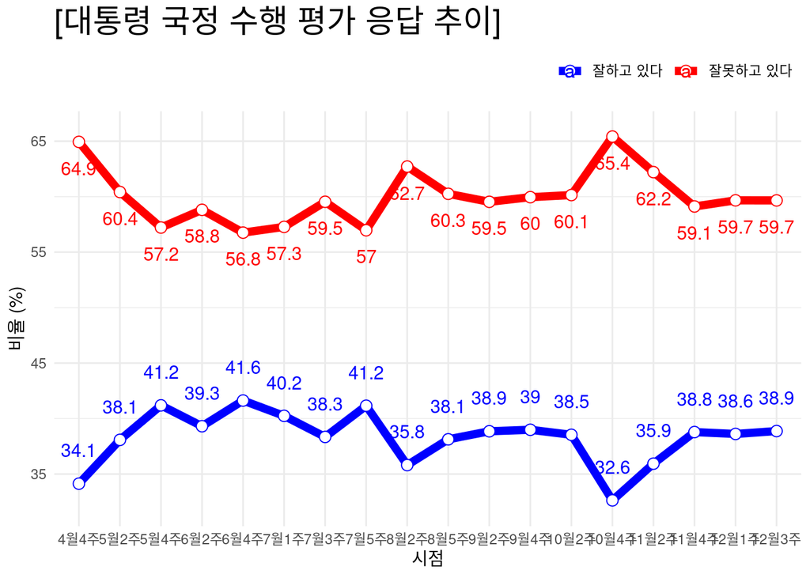

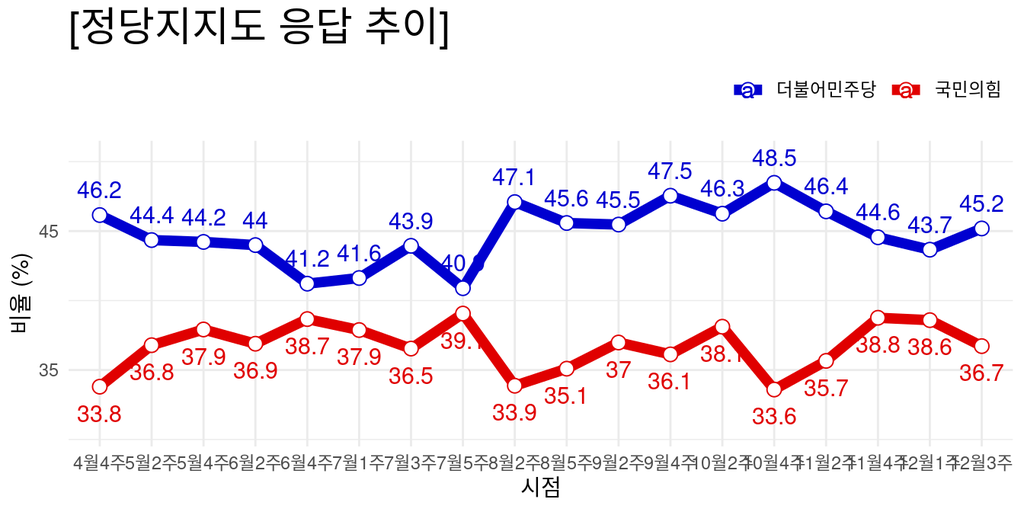

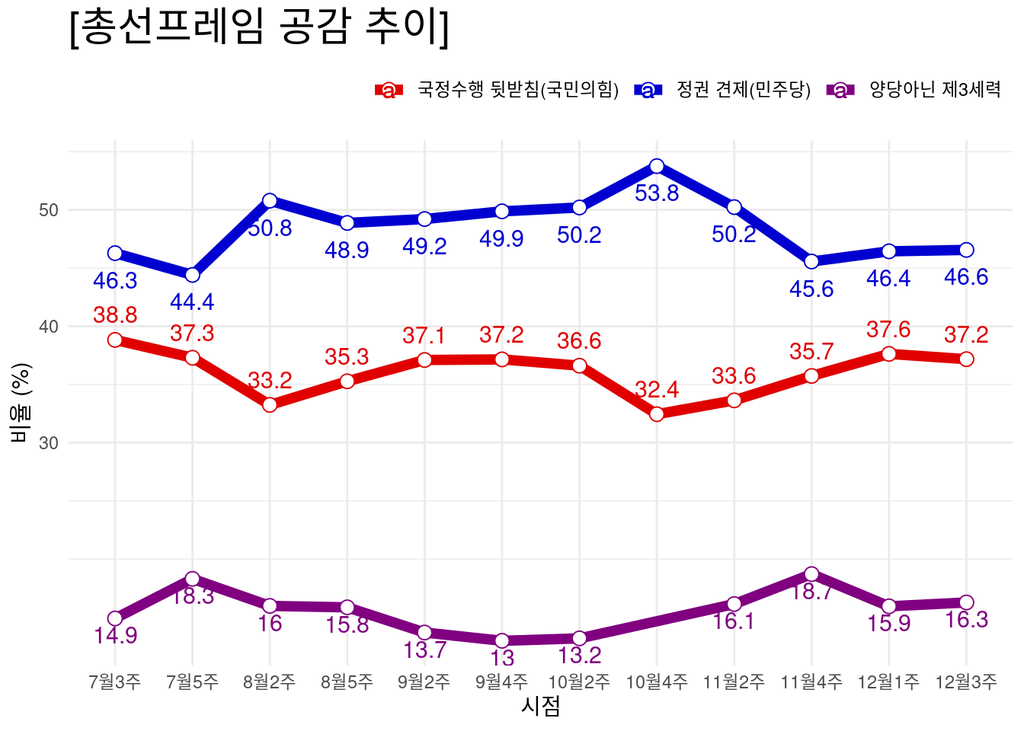

### 추가사항

- [주요질문 / 집단별 세부통계 보기](https://modernity.shinyapps.io/survey_str/) (링크누르시오)

### 참고사항

  전국 만 18세 이상 남녀를 대상으로 ARS 여론조사

  (휴대전화 100% RDD 방식, 성,연령대,지역별 비례할당 후 무작위 추출)를 실시한 결과이며,

  표본수는 2,001(총 통화시도 70,155명, 응답률 2.9%)

  ※ 가중치 부여 방식: [림가중] 성별, 연령별, 지역별 가중값 부여(2023년 11월말 행정안전부 발표 주민등록인구기준)
- [중앙선거여론조사심의위원회](https://nesdc.go.kr/portal/bbs/B0000005/list.do?menuNo=200467)에서 관련사항 확인가능

2023.12.20 (수) 13:30 제작

- 연구개발 단계입니다.
- 제공: 감동과 마음의 [조원씨앤아이](http://jowoncni.com/html/index.html)